# Demographics analysis 1 - General Admissions

General Admissions

- **These are general emergency inpatient hospital admissions**
- **This data is by QUARTER - 2016Q3 to 2021Q3**
- **SEX here is “Male”, “Female”**
- **AGE groups are in 10 year increments with (from “0-10 to”90 and over”)**
- **SIMD (Scottish Index of Multiple Deprivation)**
  - This is a quintile scale (1 = “Most Deprived”, 5 = “Least Deprived”). The most appropriate SIMD released for each year is used. REMEMBER: removed 962 NAs. There are codes in the simdqf column as to why they are NA - sometimes it’s just a general geographical groupings.
  - The SIMD uses a wide range of information for small areas (almost 7000 data zones) to identify concentrations of multiple deprivation across Scotland. Further information can be found here: https://www.gov.scot/collections/scottish-index-of-multiple-deprivation-2020/
- Total per age group
  - 0-9 years 1261
  - 10-19 years 1893
  - 20-29 years 1965
  - 30-39 years 1990
  - 40-49 years 2041
  - 50-59 years 2091
  - 60-69 years 2114
  - 70-79 years 2129
  - 80-89 years 2140
  - 90 years and over 2007
- Total per sex
  - Female 9832
  - Male 9799
- Totals per SIMD
  - 1 1042 - “Most Deprived”
  - 2 1066
  - 3 1080
  - 4 1074
  - 5 1018

https://www.publichealthscotland.scot/publications/acute-hospital-activity-and-nhs-beds-information-quarterly/acute-hospital-activity-and-nhs-beds-information-quarterly-quarter-ending-30-september-2021/glossary ^ this explains the below! A *stay* is a continuous, unbroken period of time a patient spends as an inpatient in an acute facility. A patient may change specialty, consultant, significant facility, NHS board and/or hospital during a continuous inpatient stay. Because of this, information used to assign a stay to a specific hospital or NHS board has to be taken from a single episode within a stay.

*Admissions* are when you are first admitted to hospital - This relates to individual patients. However, the same patient can be counted more than once, if they change subgroup (e.g. specialty, type of admission, NHS Board etc.). In these cases, a patient will be counted once within each subtotal, but only once in the overall total.

For example, if a patient was admitted three times in a single year, twice as an emergency admission and once as an elective admission, they would be counted once in each sub-total of emergency and elective admissions, and once in the overall total of admission types.

#### Libraries Used

```r
library(tidyverse)
library(here)
library(janitor)
```

```r
library(ggplot2)
library(infer)
```

#### Read In Cleaned Data

```r
acute_activity_agesex <- read_csv(here("../../clean_data/acute_activity_by_board_of_treatment_age_sex_clean.csv"))
acute_activity_simd <-
  read_csv(here("../../clean_data/acute_activity_by_board_of_treatment_simd_clean.csv"))
```

#### Seeing what we’re working with:

**Age**

```r
acute_activity_agesex %>%
  group_by(age) %>%
  count()
```

| age | n |
| --- | --- |
| 0-9 years | 1261 |
| 10-19 years | 1893 |
| 20-29 years | 1965 |
| 30-39 years | 1990 |
| 40-49 years | 2041 |
| 50-59 years | 2091 |
| 60-69 years | 2114 |
| 70-79 years | 2129 |
| 80-89 years | 2140 |
| 90 years and over | 2007 |

```r
# 10 year increments i.e. 0-9, 10-19... 80-89, 90 years and over
# No NA values

acute_activity_agesex %>%
  mutate(age = is.na(age)) %>%
  filter(age == TRUE)
```

| quarter | quarter_qf | hb | hbqf | location | location_qf | admission_type | admission_type_qf | sex | age | episodes | length_of_episode | average_length_of_episode | average_length_of_episode_qf | stays | length_of_stay | average_length_of_stay | average_length_of_stay_qf | total_stays_per_quarter_age | total_stays_per_quarter_sex |
| --- | --- | --- | --- | --- | --- | --- | --- | --- | --- | --- | --- | --- | --- | --- | --- | --- | --- | --- | --- |

**Sex**

```r
acute_activity_agesex %>%
  group_by(sex) %>%
  count()
```

| sex | n |
| --- | --- |
| Female | 9832 |
| Male | 9799 |

```r
# Female: 9,832   Male: 9,799
# No NA values

acute_activity_agesex %>%
  mutate(sex = is.na(age)) %>%
  filter(sex == TRUE)
```

| quarter | quarter_qf | hb | hbqf | location | location_qf | admission_type | admission_type_qf | sex | age | episodes | length_of_episode | average_length_of_episode | average_length_of_episode_qf | stays | length_of_stay | average_length_of_stay | average_length_of_stay_qf | total_stays_per_quarter_age | total_stays_per_quarter_sex |
| --- | --- | --- | --- | --- | --- | --- | --- | --- | --- | --- | --- | --- | --- | --- | --- | --- | --- | --- | --- |

**SIMD**

```r
acute_activity_simd %>%
  group_by(simd) %>%
  count()
```

| simd | n |
| --- | --- |
| 1 | 1042 |
| 2 | 1066 |
| 3 | 1080 |
| 4 | 1074 |
| 5 | 1018 |

```r
#There were 962 NAs. cleaned in R script.
```

*Remember there were 7 admission types… I chose to keep Emergency Inpatients.*

Others = Elective Inpatients, Transfers, All Day cases, All Inpatients, All Inpatients and Day cases, Not Specified

# Graphs

## Sex and stays - emergency inpatients

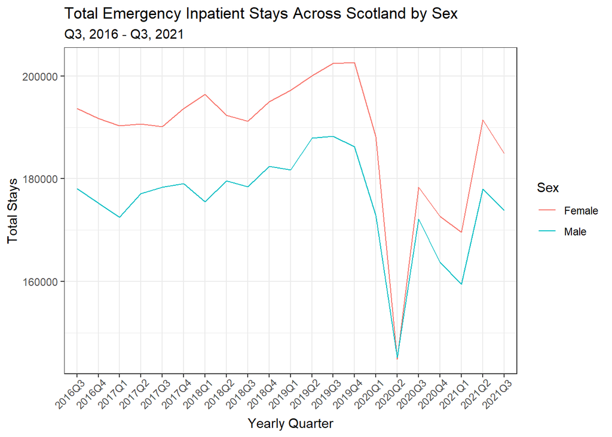

```r
acute_activity_agesex %>%
  ggplot()+
  aes(x = quarter,
      y = total_stays_per_quarter_sex,
      group = sex, colour = sex) +
  geom_line() +
  labs(x = "Yearly Quarter",
       y = "Total Stays",
       title = "Total Emergency Inpatient Stays Across Scotland by Sex",
       subtitle = "Q3, 2016 - Q3, 2021",
       colour = "Sex") +
  theme_bw()+
  theme(axis.text.x = element_text(angle=45, hjust=0.9))
```

### Statistical Investigation for Sex

#### Are you statistically more likely to be an emergency inpatient if you are a

#### female?

$$H0 : μ_{Female} - μ_{Male} = 0$$
$$H0 : μ_{Female} - μ_{Male} >
0$$

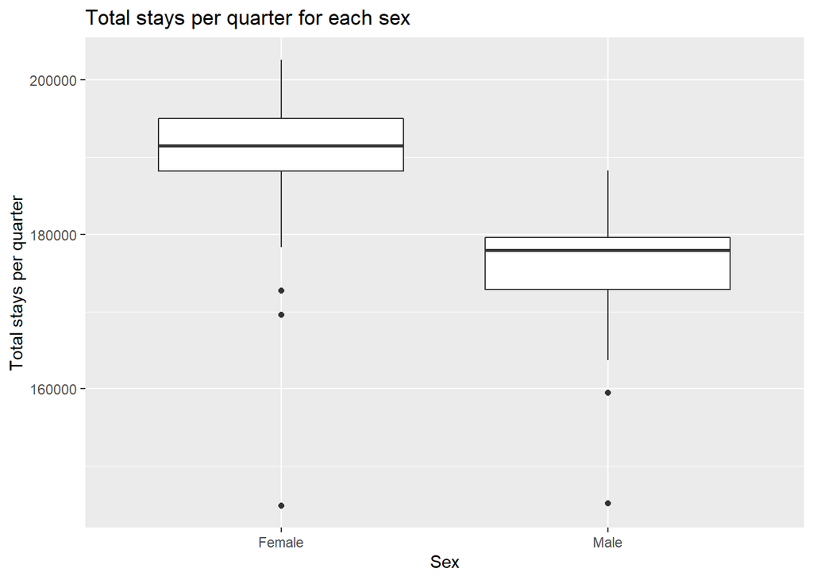

```r
acute_activity_agesex %>%
  ggplot(aes(x = sex,
             y = total_stays_per_quarter_sex,
             group = sex))+
  geom_boxplot() +
  labs(x = "Sex",
       y = "Total stays per quarter",
       title = "Total stays per quarter for each sex")
```

Permutation to generate the null distribution

```r
stays_sex <- acute_activity_agesex %>%
  filter(sex == "Female" | sex == "Male")

null_distribution_sex <- stays_sex %>%
  specify(total_stays_per_quarter_sex ~ sex) %>%
  hypothesise(null = "independence") %>%
  generate(reps = 1000, type = "permute") %>%
  calculate(stat = "diff in means", order = c("Female", "Male"))
head(null_distribution_sex)
```

| replicate | stat |
| --- | --- |
| 1 | -189.34248 |
| 2 | 193.34985 |
| 3 | 73.22583 |
| 4 | 398.97684 |
| 5 | 198.13923 |
| 6 | 71.38894 |

Observed stat:

```r
observed_stat_sex <- stays_sex %>%
  specify(total_stays_per_quarter_sex ~ sex) %>%
  calculate(stat = "diff in means", order = c("Female", "Male"))
observed_stat_sex
```

| stat |
| --- |
| 12918.76 |

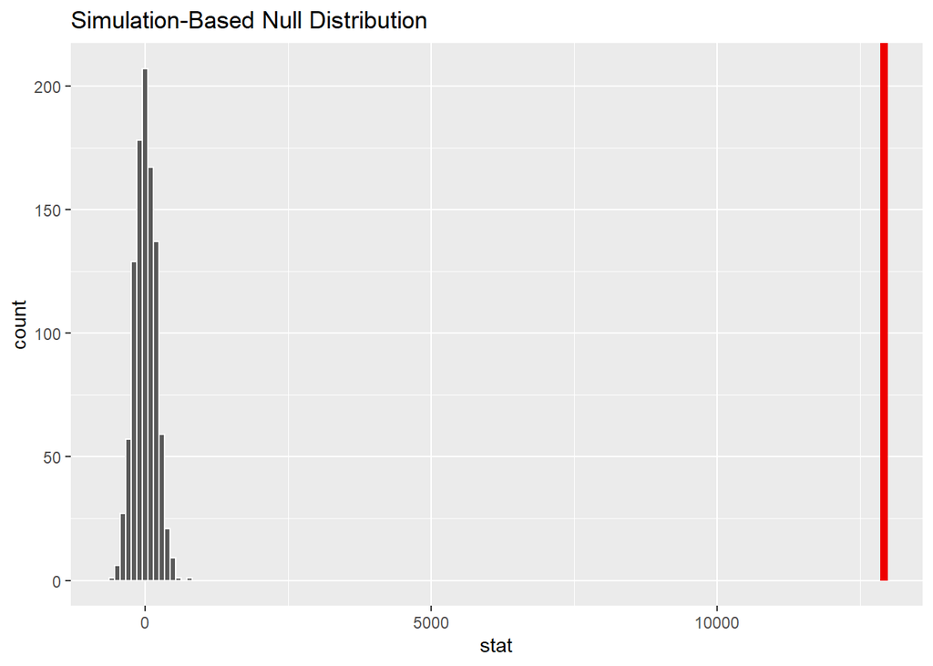

```r
null_distribution_sex %>%
  visualise()+
  shade_p_value(obs_stat = observed_stat_sex, direction = "right")
```

p-value

```r
p_value_sex <- null_distribution_sex %>%
  get_p_value(obs_stat = observed_stat_sex, direction = "right")
p_value_sex
```

| p_value |
| --- |
| 0 |

```r
format.pval(p_value_sex)
```

```
## [1] "< 2.22e-16"
```

Here, p is very close to zero (p < 2.22e-16).  
As p < 0.05, we can reject the null hypothesis in favour of the alternative hypothesis. There is statistical evidence to suggest that if you are female, you are more likely to stay in hospital as an emergency inpatient than you are if you are male.

#### Is this the case during covid alone? (are you statistically more likely to

#### stay in hospital as an emergency inpatient if you are female?)

```r
during_covid_agesex <- acute_activity_agesex %>%
  filter(quarter > "2019Q4")
```

$$H0 : μ_{Female\ (during\ covid)} -
μ_{Male\ (during\ covid)} = 0$$
$$H0 :
μ_{Female\ (during\ covid)} - μ_{Male\ (during\ covid)} >
0$$

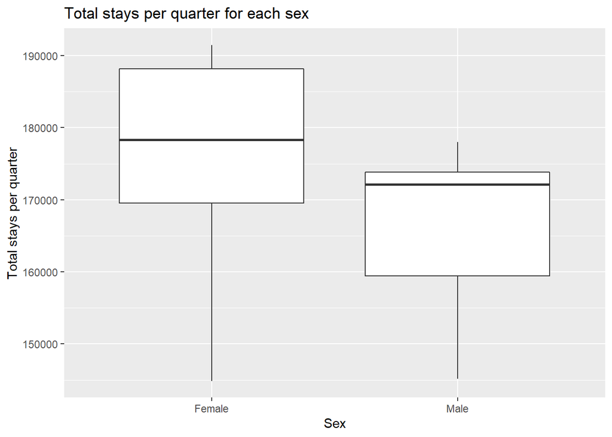

```r
during_covid_agesex %>%
  ggplot(aes(x = sex,
             y = total_stays_per_quarter_sex,
             group = sex))+
  geom_boxplot() +
  labs(x = "Sex",
       y = "Total stays per quarter",
       title = "Total stays per quarter for each sex")
```

permutation to generate the null distribution

```r
during_covid_stays_sex <- during_covid_agesex %>%
  filter(sex == "Female" | sex == "Male")

null_distribution_during_covid_sex <- during_covid_stays_sex %>%
  specify(total_stays_per_quarter_sex ~ sex) %>%
  hypothesise(null = "independence") %>%
  generate(reps = 1000, type = "permute") %>%
  calculate(stat = "diff in means", order = c("Female", "Male"))
head(null_distribution_during_covid_sex)
```

| replicate | stat |
| --- | --- |
| 1 | -417.1790 |
| 2 | 150.3183 |
| 3 | 791.5611 |
| 4 | 399.8096 |
| 5 | 124.8403 |
| 6 | -357.6775 |

observed stat:

```r
observed_stat_during_covid_sex <- during_covid_stays_sex %>%
  specify(total_stays_per_quarter_sex ~ sex) %>%
  calculate(stat = "diff in means", order = c("Female", "Male"))
observed_stat_during_covid_sex
```

| stat |
| --- |
| 9252.52 |

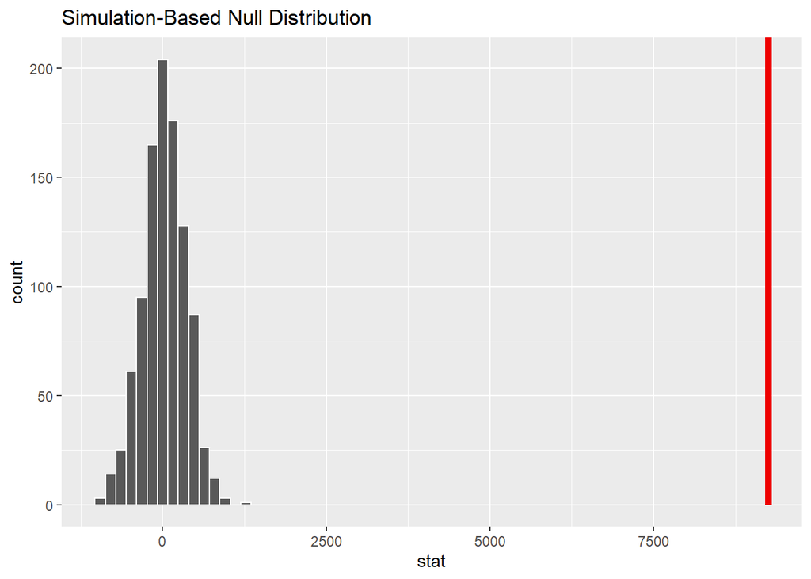

```r
null_distribution_during_covid_sex %>%
  visualise()+
  shade_p_value(obs_stat = observed_stat_during_covid_sex, direction = "right")
```

p-value

```r
p_value_during_covid_sex <- null_distribution_during_covid_sex %>%
  get_p_value(obs_stat = observed_stat_during_covid_sex, direction = "right")
p_value_during_covid_sex
```

| p_value |
| --- |
| 0 |

```r
format.pval(p_value_during_covid_sex)
```

```
## [1] "< 2.22e-16"
```

As the p value is very close to 0 (p < 2.22e-16), we can reject the null hypothesis in favour of the alternative hypothesis. There is enough statistical evidence to suggest that being female means you are more likely to stay in hospital as an emergency inpatient than if you are male.

## AGE GROUPS AND TOTAL STAYS - emergency inpatients

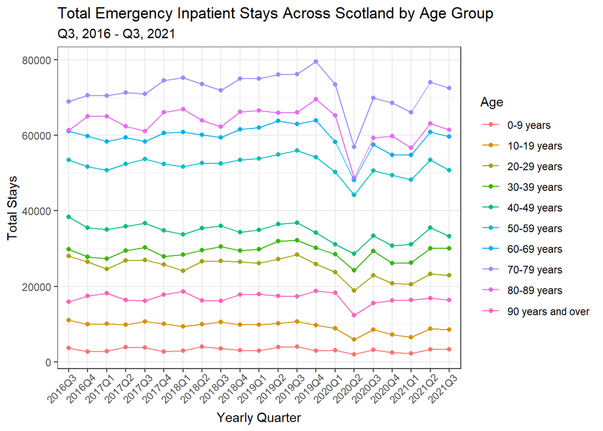

```r
acute_activity_agesex %>%
  ggplot()+
  aes(x = quarter,
      y = total_stays_per_quarter_age,
      group = age, colour = age) +
  geom_point()+
  geom_line() +
  labs(x = "Yearly Quarter",
       y = "Total Stays",
       title = "Total Emergency Inpatient Stays Across Scotland by Age Group",
       subtitle = "Q3, 2016 - Q3, 2021",
       colour = "Age") +
  theme_bw()+
  theme(axis.text.x = element_text(angle=45, hjust=0.9))
```

### Statistical Investigation for Age Groups

#### Interested in the gap - are you statistically more likely to be an

#### emergency inpatient if you are 50-59 years old than if you are 40-49?

$$H0 : μ_{Age\ Group:\ 50-59} - μ_{Age\
Group:\ 40-49} = 0$$
$$H0 : μ_{Age\
Group:\ 50-59} - μ_{Age\ Group:\ 40-49} > 0$$

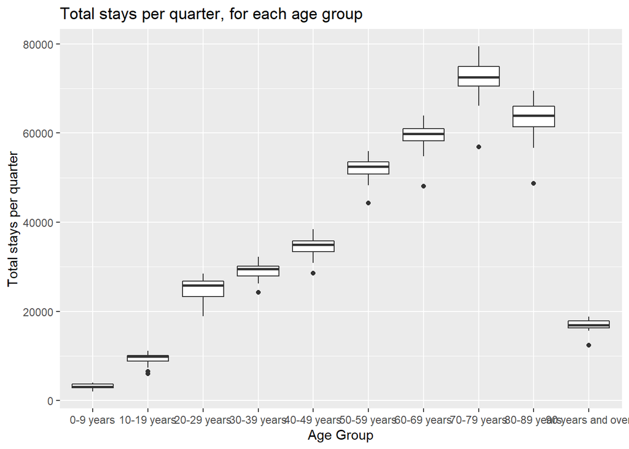

```r
acute_activity_agesex %>%
  ggplot(aes(x = age,
             y = total_stays_per_quarter_age,
             group = age))+
  geom_boxplot() +
  labs(x = "Age Group",
       y = "Total stays per quarter",
       title = "Total stays per quarter, for each age group")
```

permutation to generate the null distribution

```r
stays_age <- acute_activity_agesex %>%
  filter(age == "40-49 years" | age == "50-59 years")

null_distribution_age <- stays_age %>%
  specify(total_stays_per_quarter_age ~ age) %>%
  hypothesise(null = "independence") %>%
  generate(reps = 1000, type = "permute") %>%
  calculate(stat = "diff in means", order = c("50-59 years", "40-49 years"))
head(null_distribution_age)
```

| replicate | stat |
| --- | --- |
| 1 | -93.64005 |
| 2 | -269.60966 |
| 3 | -349.39870 |
| 4 | 47.50356 |
| 5 | -212.17628 |
| 6 | 131.69208 |

observed stat:

```r
observed_stat_age <- stays_age %>%
  specify(total_stays_per_quarter_age ~ age) %>%
  calculate(stat = "diff in means", order = c("50-59 years", "40-49 years"))
observed_stat_age
```

| stat |
| --- |
| 17536.94 |

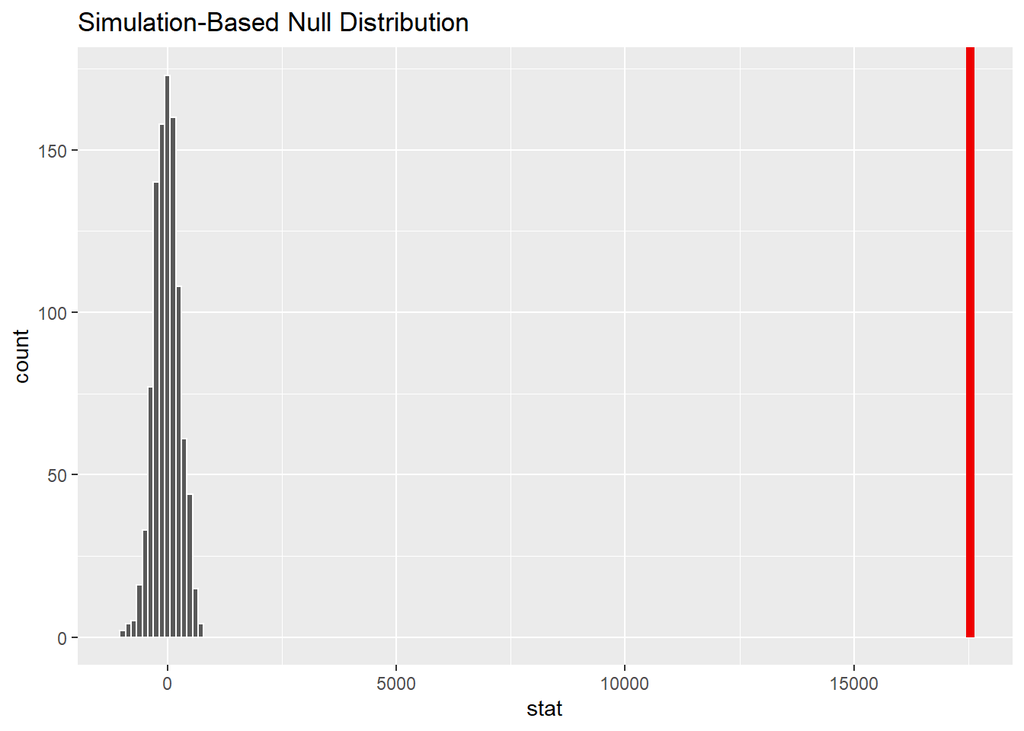

```r
null_distribution_age %>%
  visualise()+
  shade_p_value(obs_stat = observed_stat_age, direction = "right")
```

p-value

```r
p_value_age <- null_distribution_age %>%
  get_p_value(obs_stat = observed_stat_age, direction = "right")
p_value_age
```

| p_value |
| --- |
| 0 |

```r
format.pval(p_value_age)
```

```
## [1] "< 2.22e-16"
```

## SIMD - deprivation level data

#### Total stays as an emergency inpatient against SIMD quintiles

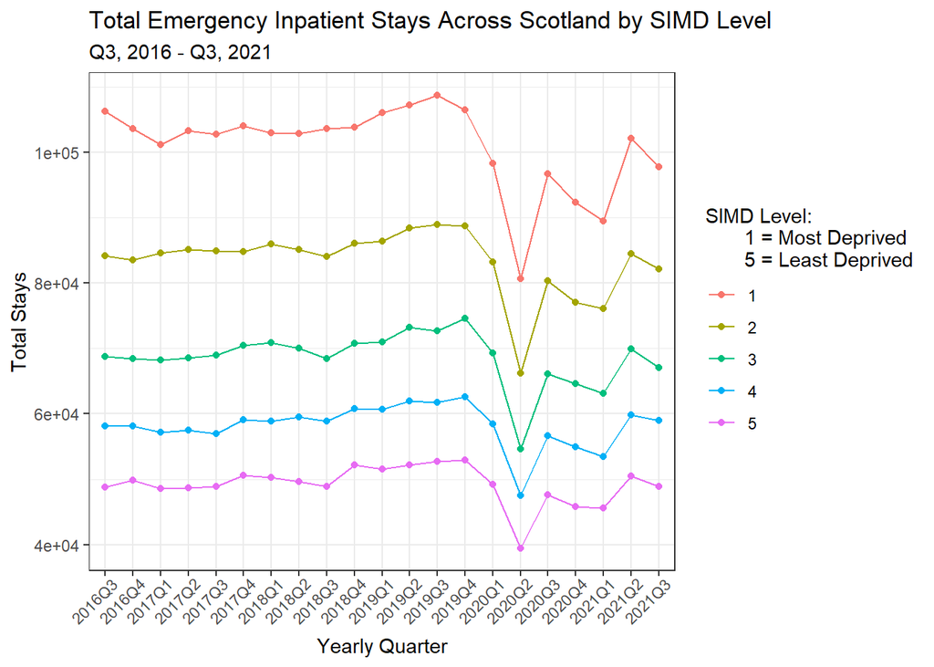

```r
acute_activity_simd %>%
     mutate(simd = fct_relevel(as.character(simd,
                                  "1", "2", "3", "4", "5"))) %>%
  ggplot()+
  aes(x = quarter,
      y = total_stays_per_quarter_simd,
      group = simd, colour = simd) +
  geom_point()+
  geom_line() +
  labs(x = "Yearly Quarter",
       y = "Total Stays",
       title = "Total Emergency Inpatient Stays Across Scotland by SIMD Level",
       subtitle = "Q3, 2016 - Q3, 2021",
       colour = "SIMD Level:
       1 = Most Deprived
       5 = Least Deprived") +
  theme_bw()+
  theme(axis.text.x = element_text(angle=45, hjust=0.9))
```

#### Comparing total EPISODES with stays(above) for SIMD

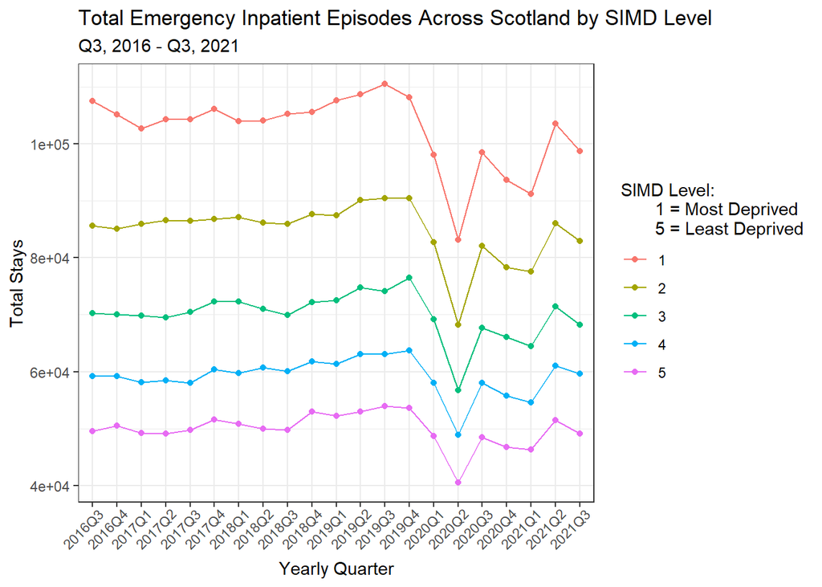

```r
acute_activity_simd %>%
     mutate(simd = fct_relevel(as.character(simd,
                                  "1", "2", "3", "4", "5"))) %>%
  ggplot()+
  aes(x = quarter,
      y = total_episodes_per_quarter_simd,
      group = simd, colour = simd) +
  geom_point()+
  geom_line() +
  labs(x = "Yearly Quarter",
       y = "Total Stays",
       title = "Total Emergency Inpatient Episodes Across Scotland by SIMD Level",
       subtitle = "Q3, 2016 - Q3, 2021",
       colour = "SIMD Level:
       1 = Most Deprived
       5 = Least Deprived") +
  theme_bw()+
  theme(axis.text.x = element_text(angle=45, hjust=0.9))
```

### STATISTICS SIMD - TOTAL STAYS (pre and post covid at after)

- Looking at all times - acute admissions as emergency inpatients - by SIMD  
  The mean of total admissions for each simd quintile:

```r
acute_activity_simd %>%
  group_by(simd) %>%
  summarise(mean_total_stays = mean(total_stays_per_quarter_simd))
```

| simd | mean_total_stays |
| --- | --- |
| 1 | 100976.09 |
| 2 | 83355.62 |
| 3 | 68557.37 |
| 4 | 58209.39 |
| 5 | 49177.69 |

#### SIMD 1 (most deprived) and SIMD 3 (mid deprivation)

#### You are more likely to have a stay in hospital if you are from a more

#### deprived area.

$$H0 : μ_{SIMD\ 1:\ (most\ deprived)} -
μ_{SIMD\ 3\ (mid\ deprived)} = 0$$
$$Ha : μ_{SIMD\ 1:\ (most\ deprived)} - μ_{SIMD\ 3\
(mid\ deprived)} > 0$$

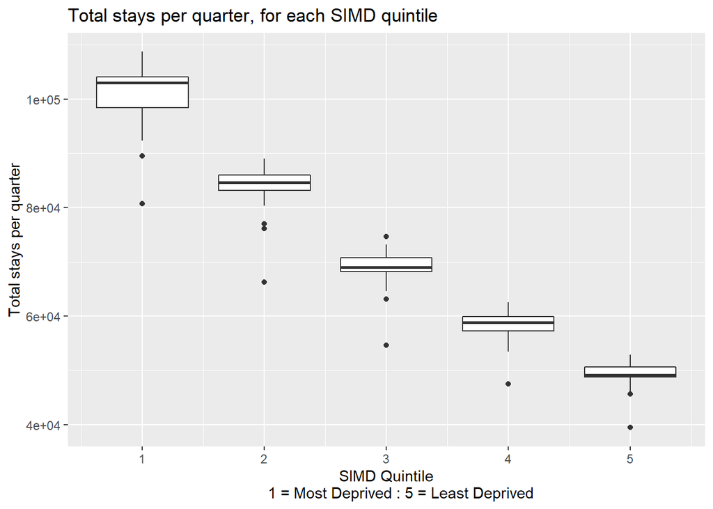

```r
acute_activity_simd %>%
  ggplot(aes(x = simd,
             y = total_stays_per_quarter_simd,
             group = simd))+
  geom_boxplot() +
  labs(x = "SIMD Quintile
       1 = Most Deprived : 5 = Least Deprived",
       y = "Total stays per quarter",
       title = "Total stays per quarter, for each SIMD quintile")
```

permutation to generate the null distribution NOTE - we only want SIMD 1 and 3 just now

```r
stays_simd_one_three <- acute_activity_simd %>%
  filter(simd == "1" | simd == "3") %>%
  mutate(simd = as.character(simd))

null_distribution_most_mid <- stays_simd_one_three %>%
  specify(total_stays_per_quarter_simd ~ simd) %>%
  hypothesise(null = "independence") %>%
  generate(reps = 1000, type = "permute") %>%
  calculate(stat = "diff in means", order = c("1", "3"))
head(null_distribution_most_mid)
```

| replicate | stat |
| --- | --- |
| 1 | -1196.64444 |
| 2 | -956.75789 |
| 3 | -464.74715 |
| 4 | -1066.93272 |
| 5 | 846.74223 |
| 6 | 63.29024 |

observed stat:

```r
observed_stat_one_three <- stays_simd_one_three %>%
  specify(total_stays_per_quarter_simd ~ simd) %>%
  calculate(stat = "diff in means", order = c("1", "3"))
observed_stat_one_three
```

| stat |
| --- |
| 32418.73 |

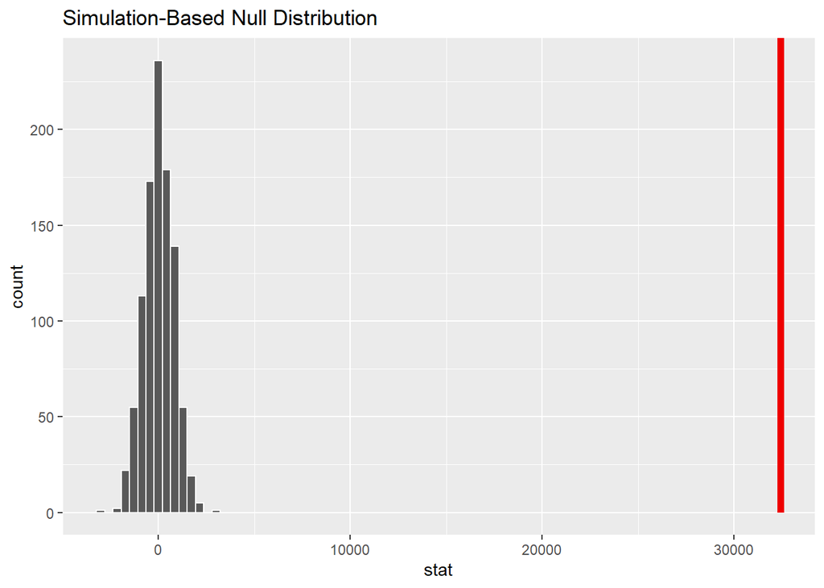

```r
null_distribution_most_mid %>%
  visualise()+
  shade_p_value(obs_stat = observed_stat_one_three, direction = "right")
```

```r
p_value <- null_distribution_most_mid %>%
  get_p_value(obs_stat = observed_stat_one_three, direction = "right")
p_value
```

| p_value |
| --- |
| 0 |

```r
format.pval(p_value)
```

```
## [1] "< 2.22e-16"
```

p = 2.22e-16, very close to 0. Therefore as p < 0.05 we can reject our null hypothesis in favour of the alternative hypothesis. The mean for total stays for SIMD 1 (Most Deprived) is significantly greater than that of SIMD 3 (mid level deprivation area) so suggests that those in more deprived areas are more likely to be admitted to hospital across all time periods pre and during covid.

#### Continued but for SIMD 3 (mid deprived) and SIMD 5 (least deprivation)

$$H0 : μ_{SIMD\ 3:\ (mid\ deprived)} -
μ_{SIMD\ 5\ (least\ deprived)} = 0$$
$$Ha : μ_{SIMD\ 3:\ (mid\ deprived)} - μ_{SIMD\ 5\
(least\ deprived)} > 0$$

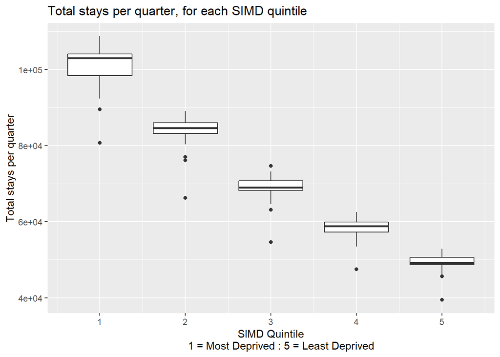

```r
acute_activity_simd %>%
  ggplot(aes(x = simd,
             y = total_stays_per_quarter_simd,
             group = simd))+
  geom_boxplot() +
  labs(x = "SIMD Quintile
       1 = Most Deprived : 5 = Least Deprived",
       y = "Total stays per quarter",
       title = "Total stays per quarter, for each SIMD quintile")
```

```r
stays_simd_three_five <- acute_activity_simd %>%
  filter(simd == "3" | simd == "5") %>%
  mutate(simd = as.character(simd))

null_distribution_mid_least <- stays_simd_three_five %>%
  specify(total_stays_per_quarter_simd ~ simd) %>%
  hypothesise(null = "independence") %>%
  generate(reps = 1000, type = "permute") %>%
  calculate(stat = "diff in means", order = c("3", "5"))
head(null_distribution_mid_least)
```

| replicate | stat |
| --- | --- |
| 1 | 43.8832 |
| 2 | 220.9511 |
| 3 | -423.6939 |
| 4 | 353.8183 |
| 5 | -121.1246 |
| 6 | 433.9340 |

observed stat:

```r
observed_stat_three_five <- stays_simd_three_five %>%
  specify(total_stays_per_quarter_simd ~ simd) %>%
  calculate(stat = "diff in means", order = c("3", "5"))
observed_stat_three_five
```

| stat |
| --- |
| 19379.68 |

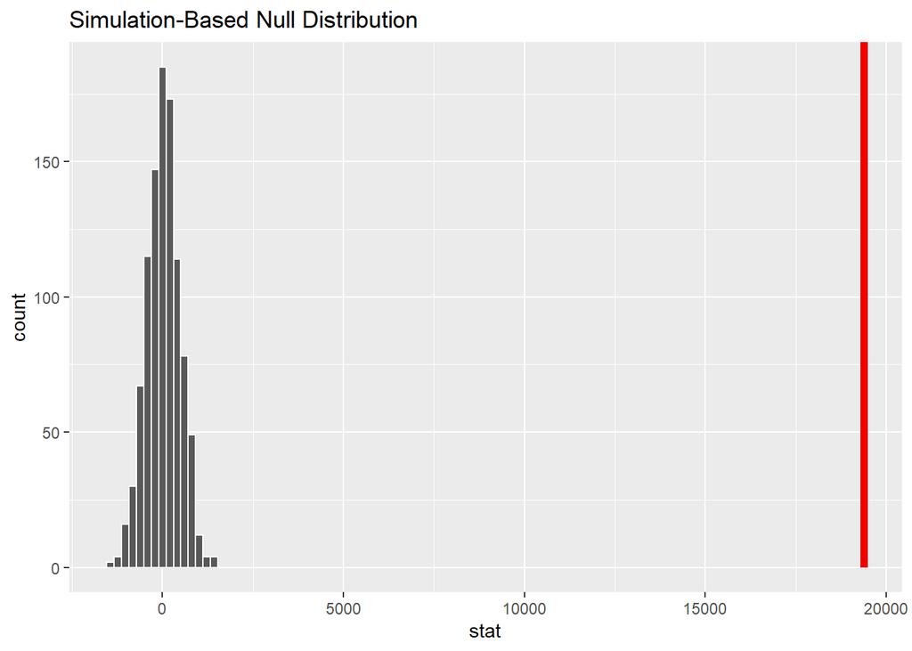

```r
null_distribution_mid_least %>%
  visualise()+
  shade_p_value(obs_stat = observed_stat_three_five, direction = "right")
```

```r
p_value <- null_distribution_mid_least %>%
  get_p_value(obs_stat = observed_stat_three_five, direction = "right")
p_value
```

| p_value |
| --- |
| 0 |

```r
format.pval(p_value)
```

```
## [1] "< 2.22e-16"
```

p = 2.22e-16 So very close to 0. Therefore as p < 0.05 we can reject our null hypothesis in favour of the alternative hypothesis. The mean for total stays for SIMD 3 (Mid) Deprived areas) is significantly greater than that of SIMD 5 (Least deprived areas) so suggests that those in more deprived areas are more likely to be admitted to hospital across all time periods pre and during covid.

#### Pre and During COVID - SIMD

#### Pre covid - 1 and 3 and During covid 1 and 3

**You are more likely to be hospitalised if you live in a more deprived area** **both before and during covid - checking the mean difference between most** **deprived and mid deprived for both time periods.**

```r
pre_covid_simd <- acute_activity_simd %>%
  filter(quarter <= "2019Q4")

post_covid_simd <- acute_activity_simd %>%
  filter(quarter >= "2020Q1")
```

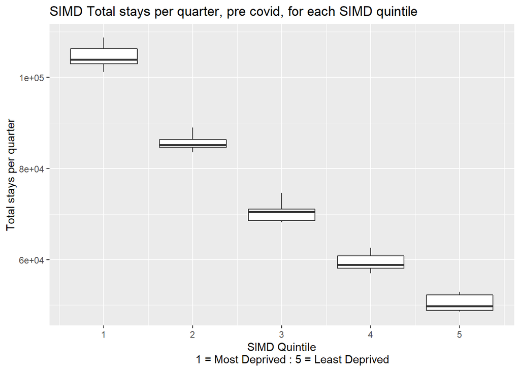

```r
pre_covid_simd %>%
  ggplot(aes(x = simd,
             y = total_stays_per_quarter_simd,
             group = simd))+
  geom_boxplot() +
  labs(x = "SIMD Quintile
       1 = Most Deprived : 5 = Least Deprived",
       y = "Total stays per quarter",
       title = "SIMD Total stays per quarter, pre covid, for each SIMD quintile")
```

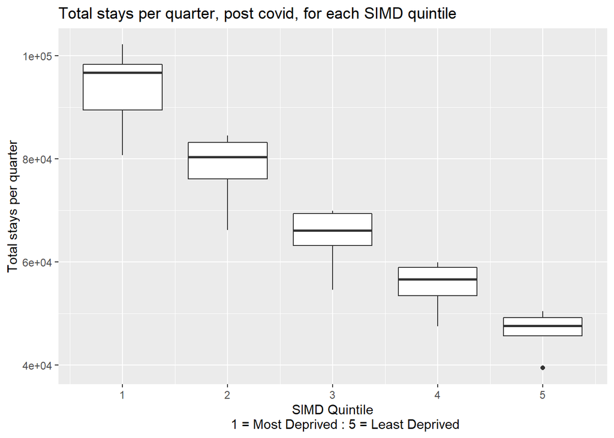

```r
post_covid_simd %>%
  ggplot(aes(x = simd,
             y = total_stays_per_quarter_simd,
             group = simd))+
  geom_boxplot() +
  labs(x = "SIMD Quintile
       1 = Most Deprived : 5 = Least Deprived",
       y = "Total stays per quarter",
       title = "Total stays per quarter, post covid, for each SIMD quintile")
```

Permutation to generate the null distribution NOTE - we only want SIMD 1 and 3 just now

```r
# pre covid
pre_covid_stays_simd_one_three <- pre_covid_simd %>%
  filter(simd == "1" | simd == "3") %>%
  mutate(simd = as.character(simd))

null_distribution_most_mid_pre_covid <- pre_covid_stays_simd_one_three %>%
  specify(total_stays_per_quarter_simd ~ simd) %>%
  hypothesise(null = "independence") %>%
  generate(reps = 1000, type = "permute") %>%
  calculate(stat = "diff in means", order = c("1", "3"))
head(null_distribution_most_mid_pre_covid)
```

| replicate | stat |
| --- | --- |
| 1 | -737.0520 |
| 2 | -916.9180 |
| 3 | 1924.2410 |
| 4 | 967.1670 |
| 5 | 508.2132 |
| 6 | -1197.7817 |

```r
# post covid
post_covid_stays_simd_one_three <- post_covid_simd %>%
  filter(simd == "1" | simd == "3") %>%
  mutate(simd = as.character(simd))

null_distribution_most_mid_post_covid <- post_covid_stays_simd_one_three %>%
  specify(total_stays_per_quarter_simd ~ simd) %>%
  hypothesise(null = "independence") %>%
  generate(reps = 1000, type = "permute") %>%
  calculate(stat = "diff in means", order = c("1", "3"))
head(null_distribution_most_mid_post_covid)
```

| replicate | stat |
| --- | --- |
| 1 | 397.9686 |
| 2 | 1089.6080 |
| 3 | 489.1494 |
| 4 | -128.6077 |
| 5 | 1735.3383 |
| 6 | 900.6226 |

observed stats:

```r
observed_stat_one_three_pre_covid <- pre_covid_stays_simd_one_three %>%
  specify(total_stays_per_quarter_simd ~ simd) %>%
  calculate(stat = "diff in means", order = c("1", "3"))
observed_stat_one_three_pre_covid
```

| stat |
| --- |
| 34186.43 |

```r
observed_stat_one_three_post_covid <- post_covid_stays_simd_one_three %>%
  specify(total_stays_per_quarter_simd ~ simd) %>%
  calculate(stat = "diff in means", order = c("1", "3"))
observed_stat_one_three_post_covid
```

| stat |
| --- |
| 29071.06 |

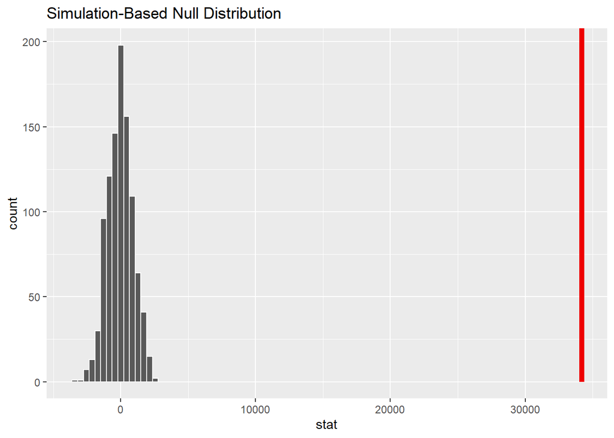

```r
null_distribution_most_mid_pre_covid %>%
  visualise()+
  shade_p_value(obs_stat = observed_stat_one_three_pre_covid,
                direction = "right")
```

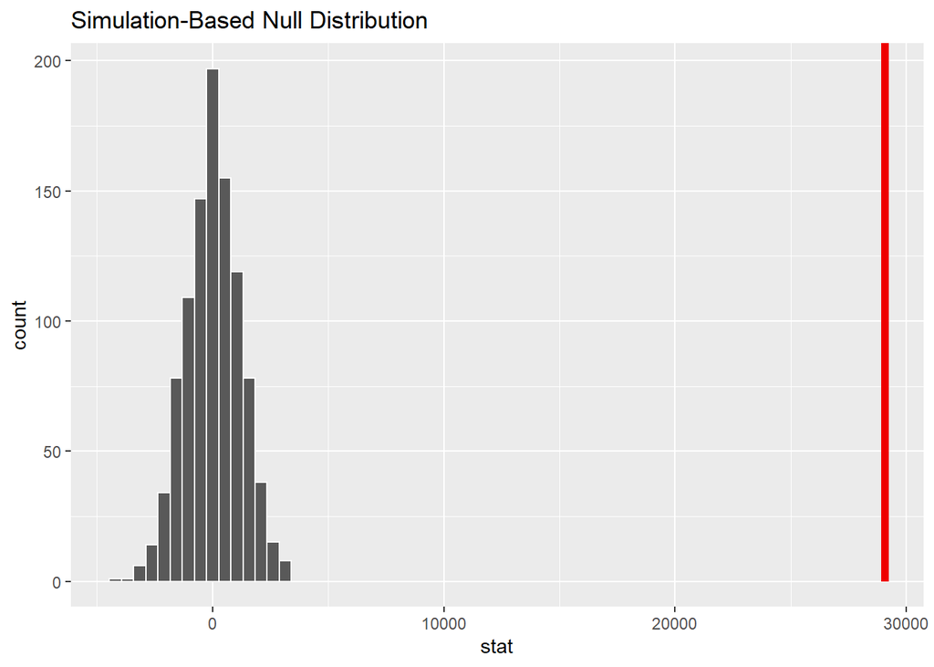

```r
null_distribution_most_mid_post_covid %>%
  visualise()+
  shade_p_value(obs_stat = observed_stat_one_three_post_covid,
                direction = "right")
```

```r
p_value_pre_covid <- null_distribution_most_mid_pre_covid %>%
  get_p_value(obs_stat = observed_stat_one_three_pre_covid, direction = "right")
p_value_pre_covid
```

| p_value |
| --- |
| 0 |

```r
format.pval(p_value_pre_covid)
```

```
## [1] "< 2.22e-16"
```

```r
p_value_post_covid <- null_distribution_most_mid_post_covid %>%
  get_p_value(obs_stat = observed_stat_one_three_post_covid,
              direction = "right")
p_value_post_covid
```

| p_value |
| --- |
| 0 |

```r
format.pval(p_value_post_covid)
```

```
## [1] "< 2.22e-16"
```

Both pre and during covid time periods show p values very close to zero.  
As p < 0.05 we can reject the null hypothesis in favour of the alternative hypothesis which states that individuals living in areas of higher deprivation are more likely to have a stay in hospital.